# Plosives results (plosion index)

Florent Dueme

08/02/2022

This is a Markdown document to present the results of the plosive (plosion index) part of the FrSpBil experiment.

In this document I am going to present the data obtained by extracting the plosion index (PI), which is a measure of the relative amplitude of the burst of a plosive, as compared to the closure phase immediately preceding it. The PI was obtained for a total of 9576 tokens from words containing the sound /b/ in initial position either in French or in Spanish. The words were produced by either French-Spanish bilinguals or monolingual controls in each language.

144 tokens were lost either due to noise in the recording or because participants did not produce the required words. I did not remove any outliers because I believe that the experiment is partly based on creating the conditions for participants to produce unusual tokens, and I could not come up with a coherent justification for what an “anormal” token could mean with regards to the PI (as opposed to something like repsonse times for example, where a common sense explication for an anormally long token is a lapse in the participant’s concentration)

# 1. Overall /b/ data

**First of all, as suggested by Clara, I compare the /b/ written with the letter <b> (to avoid an influence of orthography) for bilinguals and controls in the two languages:**

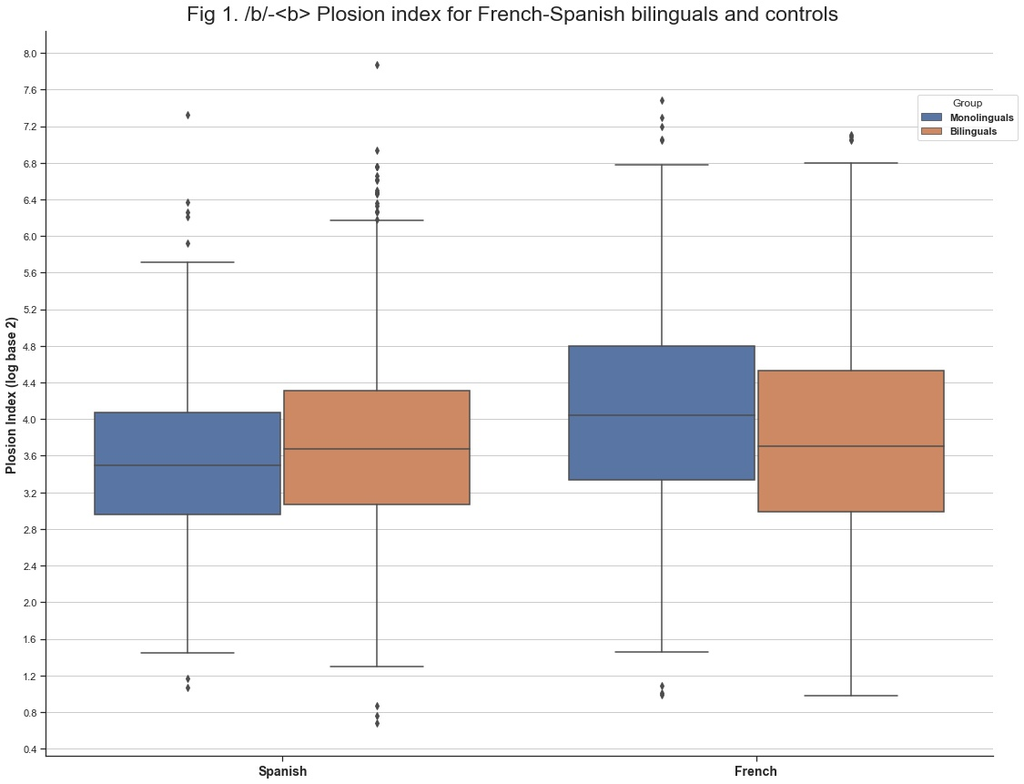

**Interestingly, it looks like bilinguals here produce /b/ exactly as energetically in French and in Spanish, and in both languages in between the controls in French and in Spanish. They are pretty far away from the French controls in French, and not as far away from the Spanish controls in Spanish, but remember that the graph is on the log scale.**

**In order to check this visual impression, I tried to fit a few model, starting with a model comparing the bilinguals’ production of /b/-<b> in French and in Spanish (with fixed effects of Language and Task and their interaction, as well as random intervals and slopes for both fixed effects). I have 2482 tokens for this data:**

```r
B_bi <-lmer(log(Plosion_index) ~ Language*Task + Gender + (1 + Language + Task|Speaker) + (1| Word), data = bi_b, contrasts = list(Task=contrast_mat))

# summary(B_bi)

tab_model(B_bi, show.se = TRUE, show.stat = TRUE, show.ci = NULL, show.re.var = FALSE)
```

|  | log(Plosion_index) |  |  |  |
| --- | --- | --- | --- | --- |
| Predictors | Estimates | std. Error | Statistic | p |
| (Intercept) | 2.69 | 0.11 | 24.78 | **<0.001** |
| Language [Spanish] | -0.04 | 0.08 | -0.51 | 0.610 |
| TaskNaming_Vs_Reading | 0.02 | 0.12 | 0.21 | 0.836 |
| TaskWord_VS_PW | 0.01 | 0.07 | 0.09 | 0.928 |
| Gender1 | 0.15 | 0.08 | 1.87 | 0.062 |
| Language [Spanish] * TaskNaming_Vs_Reading | -0.05 | 0.12 | -0.44 | 0.660 |
| Language [Spanish] * TaskWord_VS_PW | -0.05 | 0.09 | -0.57 | 0.567 |
| ICC | 0.41 |  |  |  |
| N <sub>Speaker</sub> | 21 |  |  |  |
| N <sub>Word</sub> | 81 |  |  |  |
| Observations | 2482 |  |  |  |
| Marginal R<sup>2</sup> / Conditional R<sup>2</sup> | 0.038 / 0.430 |  |  |  |

**The model confirms that as far as the plosion index is concerned, there is no difference in the way bilinguals produce /b/-<b> in Spanish and French. Then I tried to fit models to compare the bilinguals in Spanish and French with the controls in both languages, starting with French. The model had fixed effects of Group and Task and their interaction, as well as a fixed effect for gender. I had 2437 observations for this data:**

```r
B_fr <-lmer(log(Plosion_index) ~ Group*Task + Gender + (1 + Task|Speaker) + (1 + Group| Word), data = french_b, contrasts = list(Task=contrast_mat))
```

```
## boundary (singular) fit: see ?isSingular
```

```r
# summary(B_fr)

tab_model(B_fr, show.se = TRUE, show.stat = TRUE, show.ci = NULL, show.re.var = FALSE)
```

|  | log(Plosion_index) |  |  |  |
| --- | --- | --- | --- | --- |
| Predictors | Estimates | std. Error | Statistic | p |
| (Intercept) | 2.76 | 0.07 | 38.02 | **<0.001** |
| Group1 | -0.10 | 0.06 | -1.61 | 0.106 |
| TaskNaming_Vs_Reading | -0.02 | 0.13 | -0.20 | 0.844 |
| TaskWord_VS_PW | 0.04 | 0.07 | 0.49 | 0.624 |
| Gender1 | 0.07 | 0.06 | 1.09 | 0.274 |
| Group1 * TaskNaming_Vs_Reading | 0.05 | 0.12 | 0.43 | 0.664 |
| Group1 * TaskWord_VS_PW | -0.03 | 0.05 | -0.59 | 0.552 |
| N <sub>Speaker</sub> | 41 |  |  |  |
| N <sub>Word</sub> | 40 |  |  |  |
| Observations | 2437 |  |  |  |
| Marginal R<sup>2</sup> / Conditional R<sup>2</sup> | 0.046 / NA |  |  |  |

**Here is the same model in Spanish, with 2359 observations:**

```r
B_sp <-lmer(log(Plosion_index) ~ Group*Task + Gender + (1 + Task|Speaker) + (1 + Group| Word), data = spanish_b, contrasts = list(Task=contrast_mat))

# summary(B_sp)

tab_model(B_sp, show.se = TRUE, show.stat = TRUE, show.ci = NULL, show.re.var = FALSE)
```

|  | log(Plosion_index) |  |  |  |
| --- | --- | --- | --- | --- |
| Predictors | Estimates | std. Error | Statistic | p |
| (Intercept) | 2.56 | 0.06 | 40.43 | **<0.001** |
| Group1 | 0.06 | 0.05 | 1.27 | 0.206 |
| TaskNaming_Vs_Reading | -0.14 | 0.10 | -1.37 | 0.171 |
| TaskWord_VS_PW | 0.01 | 0.06 | 0.16 | 0.870 |
| Gender1 | 0.09 | 0.06 | 1.67 | 0.096 |
| Group1 * TaskNaming_Vs_Reading | 0.12 | 0.09 | 1.29 | 0.198 |
| Group1 * TaskWord_VS_PW | -0.06 | 0.04 | -1.45 | 0.146 |
| ICC | 0.36 |  |  |  |
| N <sub>Speaker</sub> | 40 |  |  |  |
| N <sub>Word</sub> | 45 |  |  |  |
| Observations | 2359 |  |  |  |
| Marginal R<sup>2</sup> / Conditional R<sup>2</sup> | 0.033 / 0.379 |  |  |  |

**In the Spanish model, the result is the same as in the French model: bilinguals are numerically different from the Spanish controls in Spanish, but the result is not quite significant.**

**In conclusion, for the plosion index data, bilinguals do not make a distinction between French /b/ and Spanish /b/. This is surprising, because in VOT they clearly had two distinct phonetic categories for the two languages. Additionally, the /b/ that they produce in the two languages appear to be in between the /b/ produced by monolinguals in each language, but in both direction the difference is not quite significant.**

# 2. French data

The data consists of 4864 tokens of the sounds /b/ - <b> and /v/ - <v> produced by the bilinguals and the French controls. With this data we were mostly interested in testing whether French-Spanish bilinguals produce a different /v/- sound than French monolingual, due to the influence of the Spanish sound /b/ that can be written .

I analyzed the data with a mixed-effects linear model. The dependent variable is the log of the PI (because the distribution is very right-skewed), with three fixed effects: Group (bilinguals vs controls), Grapheme (<b> versus <v>) and Task (herbert contrast between picture naming and the reading tasks first, then between word ans pseudoword reading), and all the interactions between these three effects. There was also a fixed effect of Gender, but no interactions between Gender and the other effects. I started with the the maximal model, and removed random effects until the model was able to converge, trying to follow the guidelines in Barr, Levy, Scheepers and Tily (2013) and Bates, Kliegl, Vasishth and Baayen (2015). (I am not showing the random effect variance in the results table, let me know if you’d like to see it)

```r
# The full model fails to converge
# PI_f_no_convergence <-lmer(log(Plosion_index) ~ Group*Grapheme*Task + Gender + (Grapheme*Task|Speaker) + (1 + Group|Word), data = french, contrasts = list(Task = contrast_mat), control=lmerControl(optCtrl=list(maxfun=50000), optimizer="bobyqa"))

# After removing some of the random slopes, a much reduced model ends up converging
PI_f <-lmer(log(Plosion_index) ~ Group*Grapheme*Task + Gender + (1 + Grapheme + Task|Speaker) + (1|Word), data = french,
            contrasts = list(Task=contrast_mat), control=lmerControl(optCtrl=list(maxfun=50000), optimizer="bobyqa"))

# summary(PI_f)
tab_model(PI_f, show.se = TRUE, show.stat = TRUE, show.ci = NULL, show.re.var = FALSE)
```

|  | log(Plosion_index) |  |  |  |
| --- | --- | --- | --- | --- |
| Predictors | Estimates | std. Error | Statistic | p |
| (Intercept) | 2.23 | 0.05 | 48.14 | **<0.001** |
| Group1 | -0.05 | 0.04 | -1.32 | 0.187 |
| Grapheme1 | -0.53 | 0.03 | -15.62 | **<0.001** |
| TaskNaming_Vs_Reading | -0.04 | 0.07 | -0.60 | 0.548 |
| TaskWord_VS_PW | -0.04 | 0.04 | -0.84 | 0.399 |
| Gender1 | 0.07 | 0.04 | 2.04 | **0.041** |
| Group1 * Grapheme1 | 0.05 | 0.03 | 1.65 | 0.100 |
| Group1 * TaskNaming_Vs_Reading | 0.02 | 0.07 | 0.28 | 0.781 |
| Group1 * TaskWord_VS_PW | -0.03 | 0.03 | -0.93 | 0.351 |
| Grapheme1 * TaskNaming_Vs_Reading | -0.02 | 0.05 | -0.44 | 0.658 |
| Grapheme1 * TaskWord_VS_PW | -0.07 | 0.04 | -1.90 | 0.057 |
| Group1 * Grapheme1 * TaskNaming_Vs_Reading | -0.03 | 0.03 | -0.96 | 0.339 |
| Group1 * Grapheme1 * TaskWord_VS_PW | 0.00 | 0.02 | 0.13 | 0.897 |
| ICC | 0.31 |  |  |  |
| N <sub>Speaker</sub> | 41 |  |  |  |
| N <sub>Word</sub> | 80 |  |  |  |
| Observations | 4864 |  |  |  |
| Marginal R<sup>2</sup> / Conditional R<sup>2</sup> | 0.413 / 0.596 |  |  |  |

If there was a difference between the way bilinguals and controls produce /v/, we would have expected to see a Group*Grapheme interaction, possibly modulated by Task. None of that is present in the data, only an obvious main effect of Grapheme, because in this French data the two graphemes <b> and <v> represent two different sounds /b/ and /v/, and a main effect of Gender, with men producing slightly more explosive sounds.

Still, the Group * Grapheme interaction has a p-value of .1, so we might as well take a look at a graph to see if anything interesting is happening. But /v/ appears to be produced exactly the same way by bilinguals and controls, if anything it is /b/ that is slightly different, being produced with a higher PI for the monolinguals than the controls, and with a higher PI from picture naming to word reading to pseudoword reading. But none of those effects are significant and even if they were true effects there would not be an easy explanation.

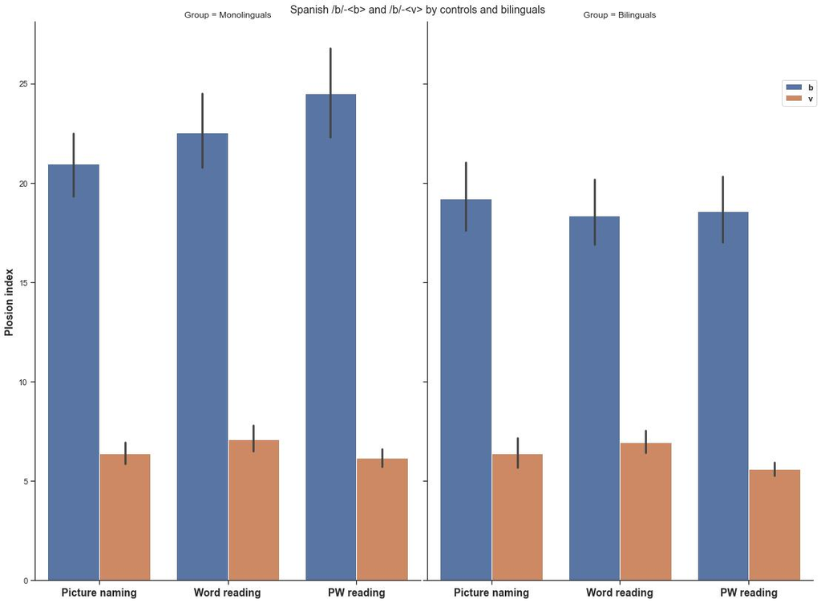

Fig 2.

# 3. Spanish data

If we take a look at the Spanish data, there appears to be a very nice interaction between orthography and group, with a higher PI in the /b/-<b> condition than in the /b/-<v> condition, but only for the bilinguals. **This data makes it look like the /b/-<v> condition is the same for the bilinguals and the controls, and that the difference between the two groups is that the /b/-<b> condition is produced with a higher plosion index by the bilinguals.**

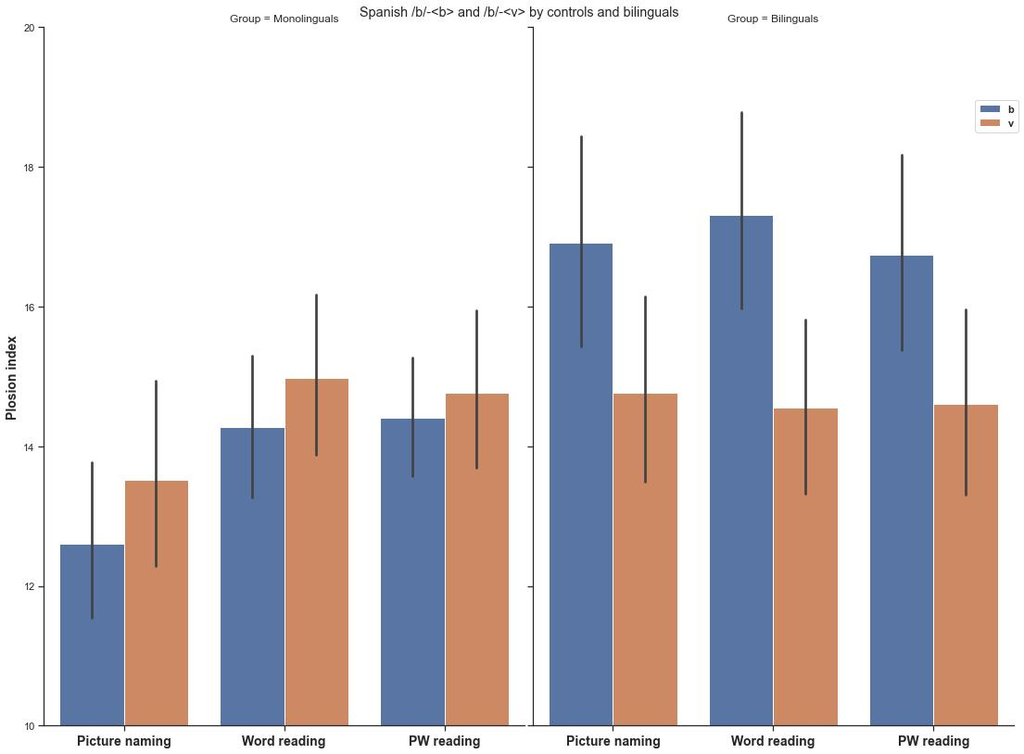

Fig 3.

I fit a similar model to the Spanish data, once again starting from a maximal model and removing random effects, but this time the model converged without removing the random slope for the effect of Group across words, so I kept it in the model. There were 4712 tokens in the Spanish data.

```r
PI_s <-lmer(log(Plosion_index) ~ Group*Grapheme*Task + Gender + (1 + Grapheme + Task|Speaker) + (1 + Group|Word), data = spanish,
contrasts = list(Task=contrast_mat), control=lmerControl(optCtrl=list(maxfun=50000), optimizer="bobyqa"))

# summary(PI_s)

tab_model(PI_s, show.se = TRUE, show.stat = TRUE, show.ci = NULL, show.re.var = FALSE)
```

|  | log(Plosion_index) |  |  |  |
| --- | --- | --- | --- | --- |
| Predictors | Estimates | std. Error | Statistic | p |
| (Intercept) | 2.52 | 0.06 | 41.52 | **<0.001** |
| Group1 | 0.01 | 0.05 | 0.21 | 0.832 |
| Grapheme1 | -0.04 | 0.02 | -2.09 | **0.037** |
| TaskNaming_Vs_Reading | -0.14 | 0.10 | -1.38 | 0.167 |
| TaskWord_VS_PW | 0.01 | 0.05 | 0.16 | 0.872 |
| Gender1 | 0.11 | 0.05 | 2.01 | **0.044** |
| Group1 * Grapheme1 | -0.05 | 0.01 | -4.40 | **<0.001** |
| Group1 * TaskNaming_Vs_Reading | 0.12 | 0.09 | 1.25 | 0.212 |
| Group1 * TaskWord_VS_PW | -0.04 | 0.04 | -1.09 | 0.277 |
| Grapheme1 * TaskNaming_Vs_Reading | 0.01 | 0.05 | 0.29 | 0.771 |
| Grapheme1 * TaskWord_VS_PW | -0.00 | 0.04 | -0.07 | 0.944 |
| Group1 * Grapheme1 * TaskNaming_Vs_Reading | -0.00 | 0.04 | -0.03 | 0.972 |
| Group1 * Grapheme1 * TaskWord_VS_PW | 0.02 | 0.02 | 0.70 | 0.486 |
| ICC | 0.37 |  |  |  |
| N <sub>Speaker</sub> | 40 |  |  |  |
| N <sub>Word</sub> | 86 |  |  |  |
| Observations | 4712 |  |  |  |
| Marginal R<sup>2</sup> / Conditional R<sup>2</sup> | 0.033 / 0.395 |  |  |  |

**Looking at the actual distribution, we can see that here the distributions appear very similar for the /b/-<b> condition produced by the bilinguals and the Spanish controls, it’s just that the whole distribution is shifted slightly upwards for the bilinguals. This is in line with what we found for the general data, that bilinguals produce the sound /b/ in Spanish in a way halfway between the French controls in French and the Spanish controls in Spanish.**

**If we look at the distributions for /b/-<v> produced by the bilinguals and the Spanish controls however, we can see that the two distributions appear very different, despite the fact that their center is roughly in the same vicinity. To me this indicates that bilinguals produce /b/-<v> in a qualitatively different way.**

There are two possibilities for this orthographic effect for the bilinguals: (1) they sometimes insert French /v/ in the /b/-<v> condition, producing a normal Spanish /b/ the rest of the time, and (2) they have a “hybrid” category for /b/-<v>, producing a sound that is neither /b/ not /v/. A look at the distribution does not seem to indicate a bimodal distribution.

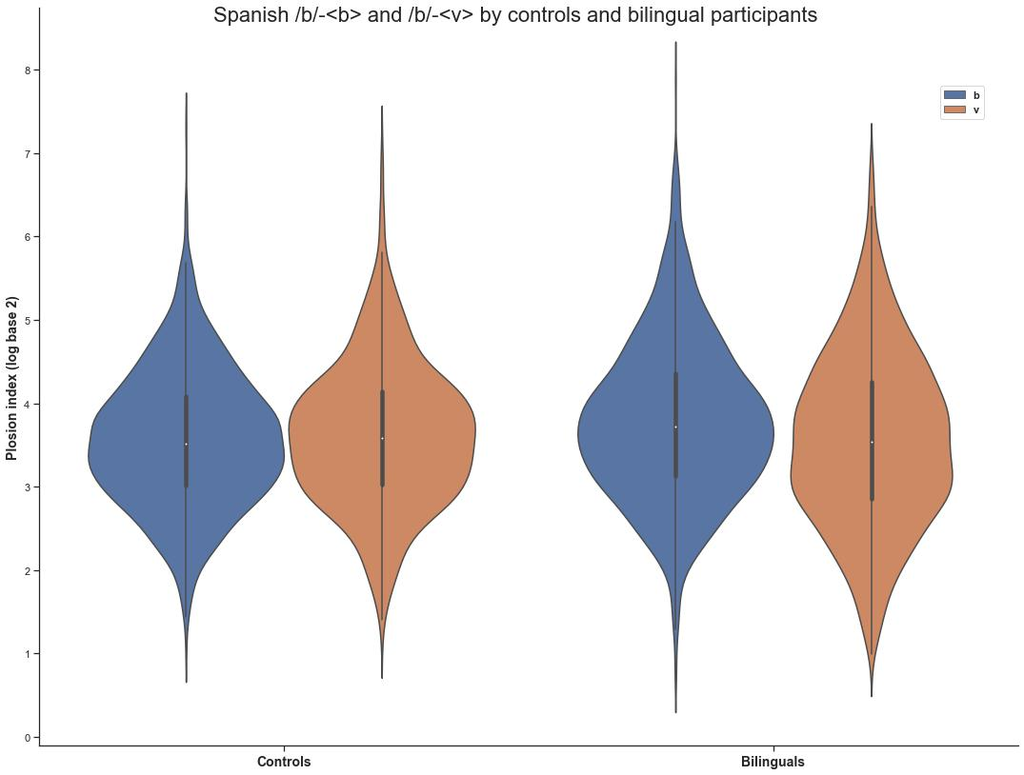

Fig 4.

Nonetheless I tried to look into whether there were more tokens produced without a burst for the bilinguals in the /b/-<v> condiition, by marking each individual token as containing a plosive burst or not. The result are shown in the following table:

```r
xtabs( ~ Group + Grapheme + Burst, data=data)
```

```
## , , Burst = 0
##
##               Grapheme
## Group             b    v
##   Monolinguals   62   62
##   Bilinguals     65  104
##
## , , Burst = 1
##
##               Grapheme
## Group             b    v
##   Monolinguals 1059 1053
##   Bilinguals   1173 1134
```

I fit a very simple logistic regression model to this data, to see if there was a bigger difference between the /b/-<b> and the /b/-<v> conditions for the bilinguals than for the controls in the number of non-plosive tokens produced. The model confirmed that it was the case.

```r
logistic <- glm(Burst ~ Group*Grapheme, data=spanish, family="binomial")

# summary(logistic)

tab_model(logistic)
```

|  | Burst |  |  |
| --- | --- | --- | --- |
| Predictors | Odds Ratios | CI | p |
| (Intercept) | 15.46 | 13.73 – 17.48 | **<0.001** |
| Group [1] | 0.91 | 0.80 – 1.02 | 0.116 |
| Grapheme [1] | 0.88 | 0.78 – 0.99 | **0.039** |
| Group [1] * Grapheme [1] | 0.88 | 0.78 – 1.00 | **0.044** |
| Observations | 4712 |  |  |
| R<sup>2</sup> Tjur | 0.003 |  |  |

These results would seem to argue in favor of explanation (1) for the effect of orthography in the bilingual group, but the difference between the bilinguals and the controls does not disappear even after excluding all the non-burst tokens from the data, as shown in the following model:

```r
# Now using only the burst tokens

spanish_plo <- spanish[spanish$Burst == 1,]

PI_s_plo <-lmer(log(Plosion_index) ~ Group*Grapheme*Task + Gender + (1 + Grapheme + Task|Speaker) + (1 + Group|Word), data = spanish_plo,
contrasts = list(Task=contrast_mat), control=lmerControl(optCtrl=list(maxfun=50000), optimizer="bobyqa"))

# summary(PI_s_plo)

tab_model(PI_s_plo, show.se = TRUE, show.stat = TRUE, show.ci = NULL, show.re.var = FALSE)
```

|  | log(Plosion_index) |  |  |  |
| --- | --- | --- | --- | --- |
| Predictors | Estimates | std. Error | Statistic | p |
| (Intercept) | 2.56 | 0.06 | 43.19 | **<0.001** |
| Group1 | 0.02 | 0.05 | 0.35 | 0.726 |
| Grapheme1 | -0.03 | 0.02 | -1.62 | 0.106 |
| TaskNaming_Vs_Reading | -0.13 | 0.09 | -1.44 | 0.150 |
| TaskWord_VS_PW | 0.02 | 0.05 | 0.33 | 0.738 |
| Gender1 | 0.11 | 0.05 | 2.18 | **0.029** |
| Group1 * Grapheme1 | -0.05 | 0.01 | -4.17 | **<0.001** |
| Group1 * TaskNaming_Vs_Reading | 0.11 | 0.08 | 1.34 | 0.182 |
| Group1 * TaskWord_VS_PW | -0.02 | 0.04 | -0.68 | 0.499 |
| Grapheme1 * TaskNaming_Vs_Reading | 0.03 | 0.05 | 0.59 | 0.556 |
| Grapheme1 * TaskWord_VS_PW | 0.00 | 0.04 | 0.11 | 0.915 |
| Group1 * Grapheme1 * TaskNaming_Vs_Reading | 0.01 | 0.04 | 0.18 | 0.853 |
| Group1 * Grapheme1 * TaskWord_VS_PW | 0.02 | 0.02 | 1.06 | 0.287 |
| ICC | 0.36 |  |  |  |
| N <sub>Speaker</sub> | 40 |  |  |  |
| N <sub>Word</sub> | 86 |  |  |  |
| Observations | 4419 |  |  |  |
| Marginal R<sup>2</sup> / Conditional R<sup>2</sup> | 0.035 / 0.381 |  |  |  |

Similarly, after removing the non-burst tokens, the distributions do not appear markedly different. The difference between the /b/-<v> condition for the bilingual group and all the other conditions mostly lies in a much flatter distribution with tokens over the whole range of the distribution. To me, this would argue in favor of both explanations (1) and (2) being true, with bilingual participants somehow “oscillating” between /b/ and /v/ in the /b/-<v> condition.

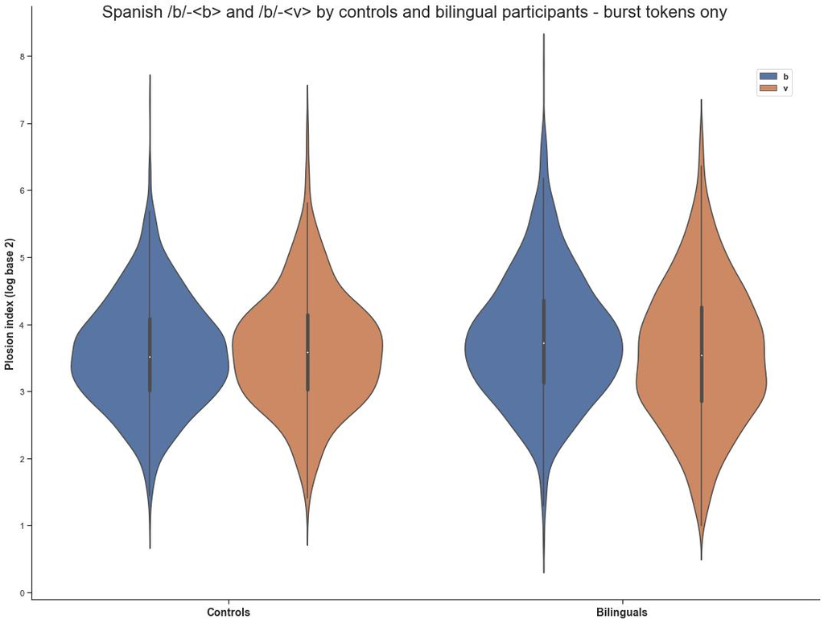

Fig 5.